# Paper figures

## Channel volumes

**Not in the paper: superseded, proposed for removal.** From the 96-run grid of 2026-10-12 (EU/RoW and North/South, four closures, period 90) or its gold baselines. The paper no longer uses this view; kept here for review.

The paper's fig-demand-structure, redrawn on the high-finance credit baselines (gold closure, t = 70): channel volumes *d* by material pair, demand channel and the pair (buying region, supplying region), with the Armington-adjusted origin shares and the operated matrix A<sub>arm</sub> the revised model uses. Investment is shown as net investment plus replacement (R4, R9). Construction is outside the revised grid. Source: R/figures/plot_revised_descriptive_figures.R.

Setup

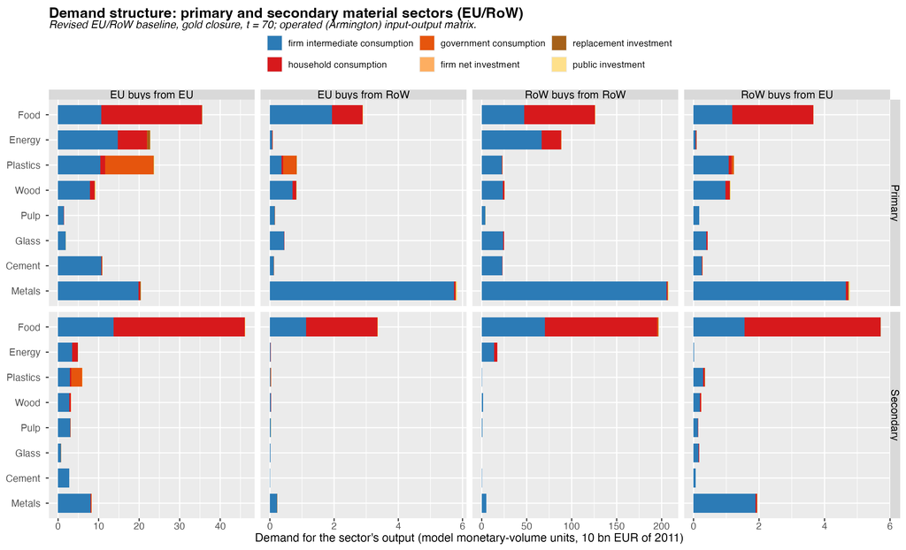

## Import decomposition

**Not in the paper: superseded, proposed for removal.** From the 96-run grid of 2026-10-12 (EU/RoW and North/South, four closures, period 90) or its gold baselines. The paper no longer uses this view; kept here for review.

The paper's fig-import-decomp, redrawn: the intervening region's purchases from the partner, 20 largest sectors, by channel. Same basis as Channel volumes.

Setup

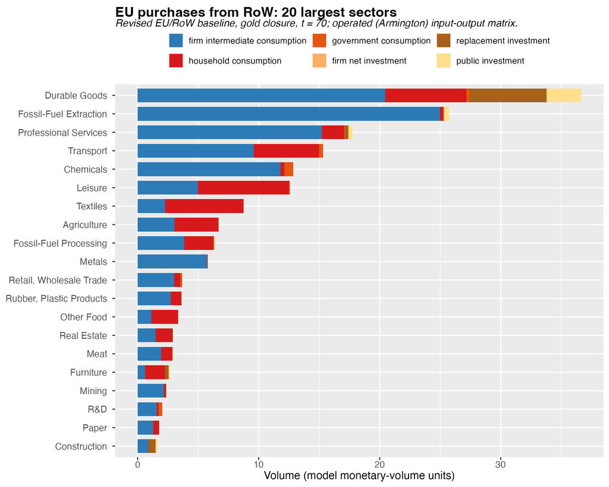

## Upstream requirements

**Not in the paper: superseded, proposed for removal.** From the 96-run grid of 2026-10-12 (EU/RoW and North/South, four closures, period 90) or its gold baselines. The paper no longer uses this view; kept here for review.

The paper's fig-leontief, redrawn: the columns of L − I (L = (I − A<sub>arm</sub>)<sup>−1</sup>, both regions' 108 sectors) for the intervening region's eight primary material sectors; the 20 supplying sectors with the largest summed requirement. Monetary-volume requirements per unit of final demand, not a physical footprint.

Setup

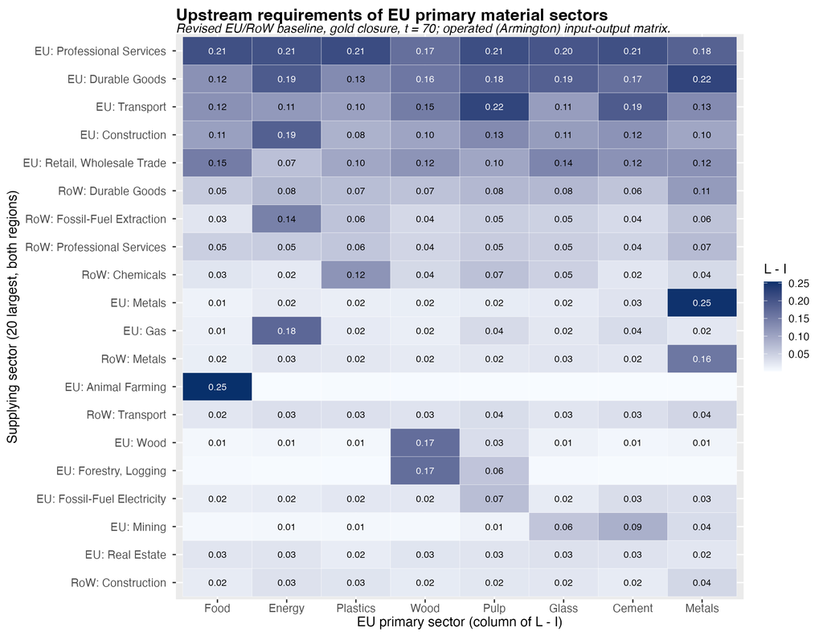

## Channel reach

**Not in the paper: superseded, proposed for removal.** From the 96-run grid of 2026-10-12 (EU/RoW and North/South, four closures, period 90) or its gold baselines. The paper no longer uses this view; kept here for review.

## Emission grid

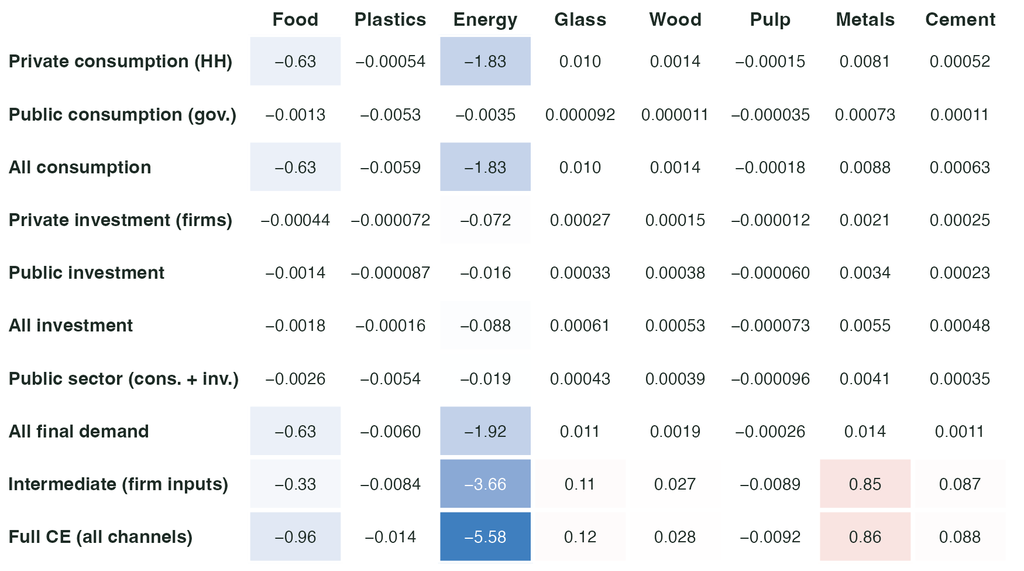

The paper's fig-emis-impact, recomputed: the analytical first-order emission change of each primary-to-secondary substitution, by channel, on the high-finance credit gold baselines. The Z1, level, submitted view reproduces the published figure.

## Material grid

**Not in the paper: superseded, proposed for removal.** From the 96-run grid of 2026-10-12 (EU/RoW and North/South, four closures, period 90) or its gold baselines. The paper no longer uses this view; kept here for review.

As the emission grid, weighted by primary-material intensity (mu_mat, material per unit output).

## Land grid

**Not in the paper: superseded, proposed for removal.** From the 96-run grid of 2026-10-12 (EU/RoW and North/South, four closures, period 90) or its gold baselines. The paper no longer uses this view; kept here for review.

As the emission grid, weighted by land per unit output (land_j / x). Land units of the workbooks are untraced (reviewer item R2.9).

## Water grid

**Not in the paper: superseded, proposed for removal.** From the 96-run grid of 2026-10-12 (EU/RoW and North/South, four closures, period 90) or its gold baselines. The paper no longer uses this view; kept here for review.

As the emission grid, weighted by water per unit output (water_j / x). Water units of the workbooks are untraced (reviewer item R2.9).

## Cross-border responses

**Not in the paper: superseded, proposed for removal.** From the 96-run grid of 2026-10-12 (EU/RoW and North/South, four closures, period 90) or its gold baselines. The paper no longer uses this view; kept here for review.

The paper's fig-cross-border, redrawn: the intervening region's response (horizontal) against the partner's (vertical) for six outcomes, coloured by value-added regime. The submitted figure's dual-inequality panel is replaced by the debt/GDP and current-account panels, which carry the closure differences.

Setup and closure

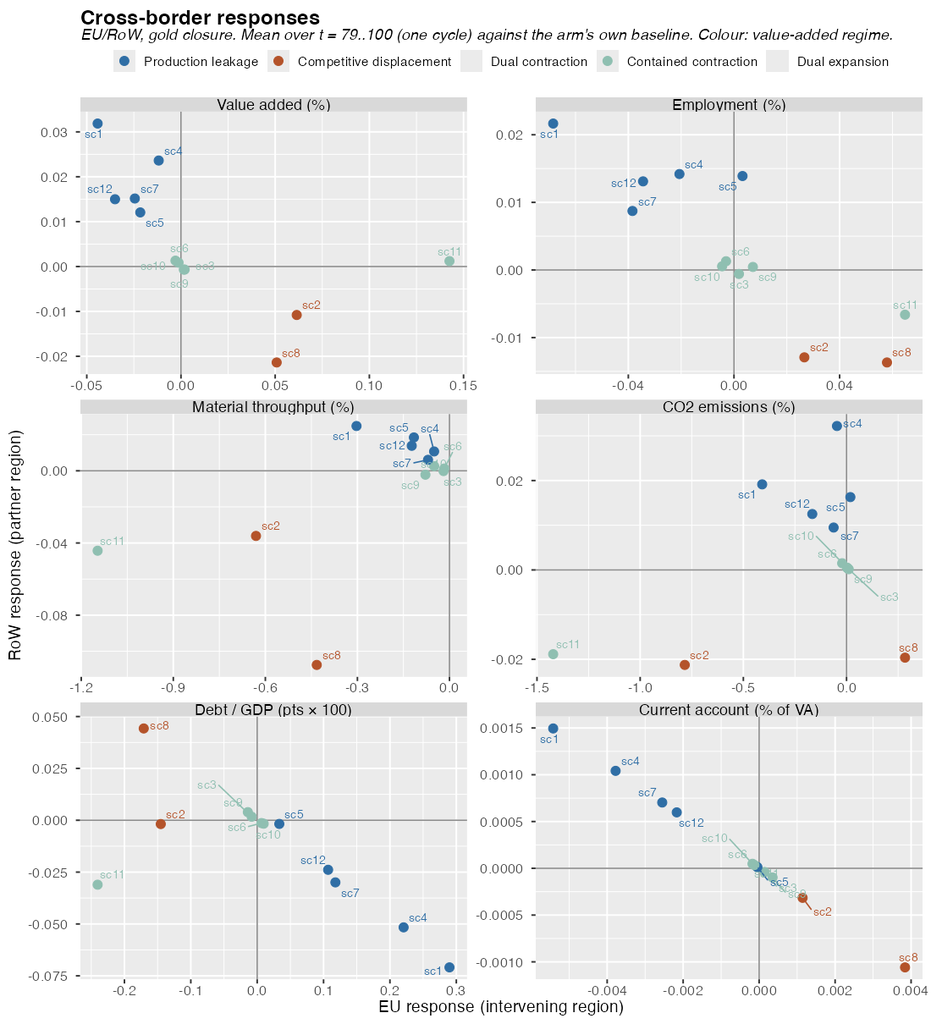

## Intervening region

**Not in the paper: superseded, proposed for removal.** From the 96-run grid of 2026-10-12 (EU/RoW and North/South, four closures, period 90) or its gold baselines. The paper no longer uses this view; kept here for review.

Setup and closure

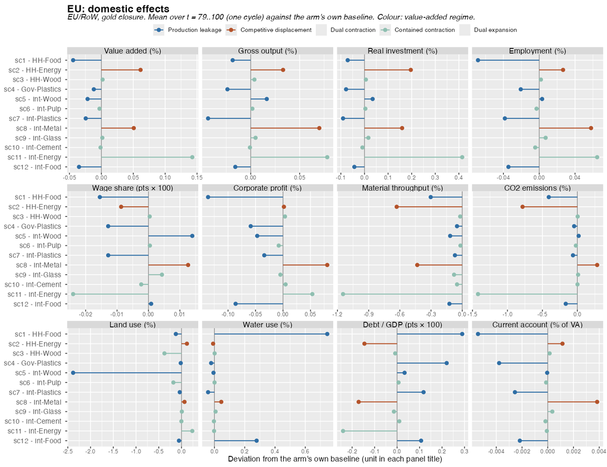

## Partner region

**Not in the paper: superseded, proposed for removal.** From the 96-run grid of 2026-10-12 (EU/RoW and North/South, four closures, period 90) or its gold baselines. The paper no longer uses this view; kept here for review.

The paper's fig-comparison-row, redrawn: the same twelve outcomes for the partner region (RoW or South).

Setup and closure

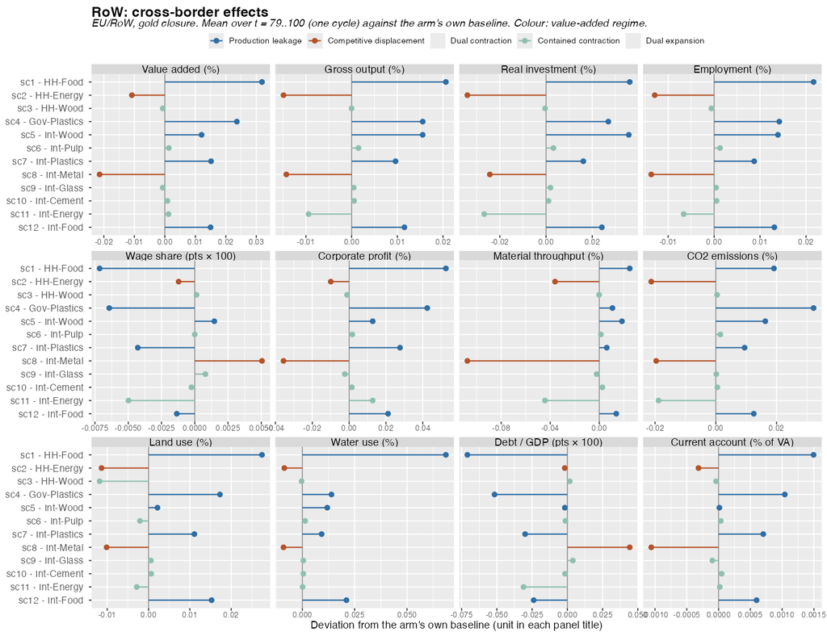